# Proyecto_RNAseq

## Obtencion de la libreria y los proyectos disponibles

```r
library("recount3")
projects<-available_projects()
```

```
## 2021-02-28 21:08:12 caching file sra.recount_project.MD.gz.
```

```
## 2021-02-28 21:08:14 caching file gtex.recount_project.MD.gz.
```

```
## 2021-02-28 21:08:15 caching file tcga.recount_project.MD.gz.
```

## Obtencion del proyecto SRP117164

Informacion de muestras del estudio **Transcriptome profiles of POM121-knockout prostate cancer cell lines**

POM121 es una proteína transmembranal de un solo paso por la membrana, que colabora con la inserción del complejo de poro nuclear (NPC) en la envoltura nuclear mediante su dominio N-terminal, ayudando con la fusión de las membranas en la interfase junto con otras proteínas nucleares, esto logrado al reducir el espacio intermembranal de la envoltura nuclear. Además que ayuda con la formación de esta envoltura, el transporte nucleocitoplasmático y la apoptosis celular.

se ha encontrado a POM121 sobreexpresada en muestras de varios tipos de cancer, incluyendo el de prostata.

```r
#Descarga del proyecto
proj_info <- subset(
    projects,
    project == "SRP117164" & project_type == "data_sources"
)
```

```r
rse<-create_rse(proj_info)
```

```
## 2021-02-28 21:08:25 downloading and reading the metadata.
```

```
## 2021-02-28 21:08:28 caching file sra.sra.SRP117164.MD.gz.
```

```
## 2021-02-28 21:08:29 caching file sra.recount_project.SRP117164.MD.gz.
```

```
## 2021-02-28 21:08:31 caching file sra.recount_qc.SRP117164.MD.gz.
```

```
## 2021-02-28 21:08:32 caching file sra.recount_seq_qc.SRP117164.MD.gz.
```

```
## 2021-02-28 21:08:34 caching file sra.recount_pred.SRP117164.MD.gz.
```

```
## 2021-02-28 21:08:36 downloading and reading the feature information.
```

```
## 2021-02-28 21:08:37 caching file human.gene_sums.G026.gtf.gz.
```

```
## 2021-02-28 21:08:39 downloading and reading the counts: 24 samples across 63856 features.
```

```
## 2021-02-28 21:08:41 caching file sra.gene_sums.SRP117164.G026.gz.
```

```
## 2021-02-28 21:08:42 construcing the RangedSummarizedExperiment (rse) object.
```

# Exploracion de los datos obtenidos

```r
rse
```

```
## class: RangedSummarizedExperiment
## dim: 63856 24
## metadata(8): time_created recount3_version ... annotation recount3_url
## assays(1): raw_counts
## rownames(63856): ENSG00000278704.1 ENSG00000277400.1 ...
##   ENSG00000182484.15_PAR_Y ENSG00000227159.8_PAR_Y
## rowData names(10): source type ... havana_gene tag
## colnames(24): SRR6021524 SRR6021525 ... SRR6021546 SRR6021547
## colData names(175): rail_id external_id ...
##   recount_pred.curated.cell_line BigWigURL
```

```r
assay(rse, "counts") <- compute_read_counts(rse)
print("Atributos")
```

```
## [1] "Atributos"
```

```r
rse$sra.sample_attributes[1:3]
```

```
## [1] "cell line;;DU145-DR|condition;;Control|source_name;;Cell line|transduced construct;;Control"
## [2] "cell line;;DU145-DR|condition;;Control|source_name;;Cell line|transduced construct;;Control"
## [3] "cell line;;DU145-DR|condition;;Control|source_name;;Cell line|transduced construct;;Control"
```

```
Se analizan 63856 genes de las 24 muestras y los atributos de las muestras parecen ser los mismos.
```

```r
rse <- expand_sra_attributes(rse)
colData(rse)[
    ,
    grepl("^sra_attribute", colnames(colData(rse)))
]
```

```
## DataFrame with 24 rows and 4 columns
##            sra_attribute.cell_line sra_attribute.condition
##                        <character>             <character>
## SRR6021524                DU145-DR                 Control
## SRR6021525                DU145-DR                 Control
## SRR6021526                DU145-DR                 Control
## SRR6021527                DU145-DR                 Control
## SRR6021528                DU145-DR                Knockout
## ...                            ...                     ...
## SRR6021543                22Rv1-DR                Knockout
## SRR6021544                22Rv1-DR                Knockout
## SRR6021545                22Rv1-DR                Knockout
## SRR6021546                22Rv1-DR                Knockout
## SRR6021547                22Rv1-DR                Knockout
##            sra_attribute.source_name sra_attribute.transduced_construct
##                          <character>                        <character>
## SRR6021524                 Cell line                            Control
## SRR6021525                 Cell line                            Control
## SRR6021526                 Cell line                            Control
## SRR6021527                 Cell line                            Control
## SRR6021528                 Cell line              siPOM121, construct 1
## ...                              ...                                ...
## SRR6021543                 Cell line              siPOM121, construct 1
## SRR6021544                 Cell line              siPOM121, construct 2
## SRR6021545                 Cell line              siPOM121, construct 2
## SRR6021546                 Cell line              siPOM121, construct 2
## SRR6021547                 Cell line              siPOM121, construct 2
```

Se realiza un reasignacion a los atributos que lo necesiten

```r
rse$sra_attribute.source_name<- factor(rse$sra_attribute.source_name)
rse$sra_attribute.cell_line<- factor(rse$sra_attribute.cell_line)
rse$sra_attribute.transduced_construct<- factor(rse$sra_attribute.transduced_construct)
```

```r
summary(as.data.frame(colData(rse)[
    ,
    grepl("^sra_attribute.[condition|source.name|cell_line|transduced_construct]", colnames(colData(rse)))
]))
```

```
##  sra_attribute.cell_line sra_attribute.condition sra_attribute.source_name
##  22Rv1-DR:12             Length:24               Cell line:24
##  DU145-DR:12             Class :character
##                          Mode  :character
##      sra_attribute.transduced_construct
##  Control              :8
##  siPOM121, construct 1:8
##  siPOM121, construct 2:8
```

Las variables se creearan en base a la prescencia de POM121

```r
rse$POM121 <- factor(ifelse(rse$sra_attribute.condition == "Control", "Control", "Knockout"))
table(rse$POM121)
```

```
##
##  Control Knockout
##        8       16
```

### Control de calidad

```r
rse$assigned_gene_prop <- rse$recount_qc.gene_fc_count_all.assigned / rse$recount_qc.gene_fc_count_all.total
summary(rse$assigned_gene_prop)
```

```
##    Min. 1st Qu.  Median    Mean 3rd Qu.    Max.
##  0.5630  0.6205  0.6841  0.6773  0.7342  0.7611
```

```r
rse_unfiltered <- rse
with(colData(rse), tapply(assigned_gene_prop, POM121 , summary))
```

```
## $Control
##    Min. 1st Qu.  Median    Mean 3rd Qu.    Max.
##  0.6208  0.6386  0.6940  0.6925  0.7475  0.7611
##
## $Knockout
##    Min. 1st Qu.  Median    Mean 3rd Qu.    Max.
##  0.5630  0.6187  0.6798  0.6697  0.7308  0.7359
```

### Eliminamos las muestras de mala calidad

Se quitaran los más bajos que el primer quantil (0.62)

```r
table(rse$assigned_gene_prop < 0.62)
```

```
##
## FALSE  TRUE
##    18     6
```

```r
rse <- rse[, rse$assigned_gene_prop > 0.62]
```

### Niveles de expresión en las muestras

```r
gene_means <- rowMeans(assay(rse, "counts"))
summary(gene_means)
```

```
##      Min.   1st Qu.    Median      Mean   3rd Qu.      Max.
##      0.00      0.00      0.39    295.31     50.22 107989.44
```

Se quitaran los que esten en 0.0

```r
rse <- rse[gene_means > 0.0, ]
```

```r
filtered_rse<-rse
```

Dimensiones finales:

```r
dim(rse)
```

```
## [1] 41921    18
```

## Normalización de los datos

Haciendo uso del paquete edgeR y limma

```r
library("limma")
library("edgeR") # BiocManager::install("edgeR", update = FALSE)
dge <- DGEList(
    counts = assay(rse, "counts"),
    genes = rowData(rse)
)
dge <- calcNormFactors(dge)
```

# Expresion diferencial

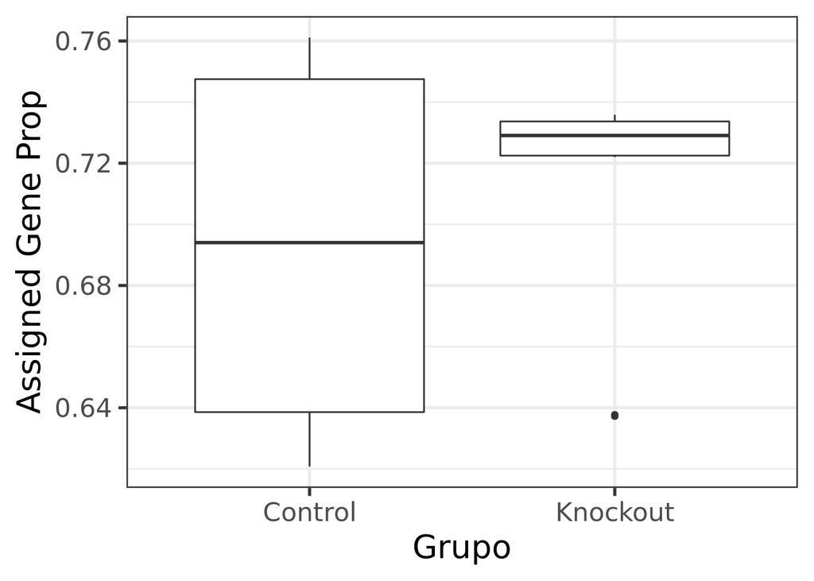

```r
library("ggplot2")
ggplot(as.data.frame(colData(rse)), aes(y = assigned_gene_prop, x =POM121)) +
    geom_boxplot() +
    theme_bw(base_size = 20) +
    ylab("Assigned Gene Prop") +
    xlab("Grupo")
```

Acerca de las otras variables

```r
unique(rse$sra_attribute.cell_line)
```

```
## [1] DU145-DR 22Rv1-DR
## Levels: 22Rv1-DR DU145-DR
```

```r
unique(rse$sra_attribute.transduced_construct)
```

```
## [1] Control               siPOM121, construct 1 siPOM121, construct 2
## Levels: Control siPOM121, construct 1 siPOM121, construct 2
```

## Modelo

### Evalucion del modelo

```r
# if (interactive()) {
#       ExploreModelMatrix::ExploreModelMatrix(
#           colData(rse)[, c(
#               "POM121", "assigned_gene_prop", "sra_attribute.cell_line","sra_attribute.transduced_construct"
#           )],
#          ~ POM121 + assigned_gene_prop +sra_attribute.cell_line
#      )
#  }
```

Las lineas anteriores su utilizaron para comprobar que el modelo no tuviera variables dependientes. al involucrar a la variable sra_attribute.transduced_construct el modelo no era full rank, por lo que fue omitida

```r
mod <- model.matrix(~ POM121 + assigned_gene_prop +sra_attribute.cell_line ,
    data = colData(rse)
)
colnames(mod)
```

```
## [1] "(Intercept)"                     "POM121Knockout"
## [3] "assigned_gene_prop"              "sra_attribute.cell_lineDU145-DR"
```

# Expresión diferencial

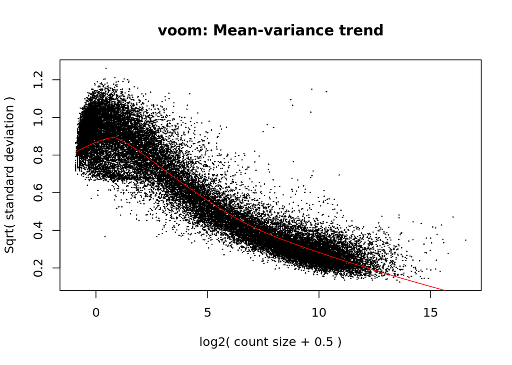

```r
vGene <- voom(dge, mod, plot = TRUE)
```

```r
eb_results <- eBayes(lmFit(vGene))

de_results <- topTable(
    eb_results,
    coef = 2,
    number = nrow(rse),
    sort.by = "none"
)
dim(de_results)
```

```
## [1] 41921    16
```

```r
table(de_results$adj.P.Val < 0.05)
```

```
##
## FALSE  TRUE
## 34896  7025
```

```r
indices<-de_results$adj.P.Val < 0.05
indices<-which(indices,arr.ind = TRUE)
```

Con base en nuestro modelo 7025 genes tienen una expresión diferencial.

```r
NomGenes<-de_results$gene_name[indices]
```

En la siguiente grafica los 10 primeros genes con expresion diferencial estan resaltados

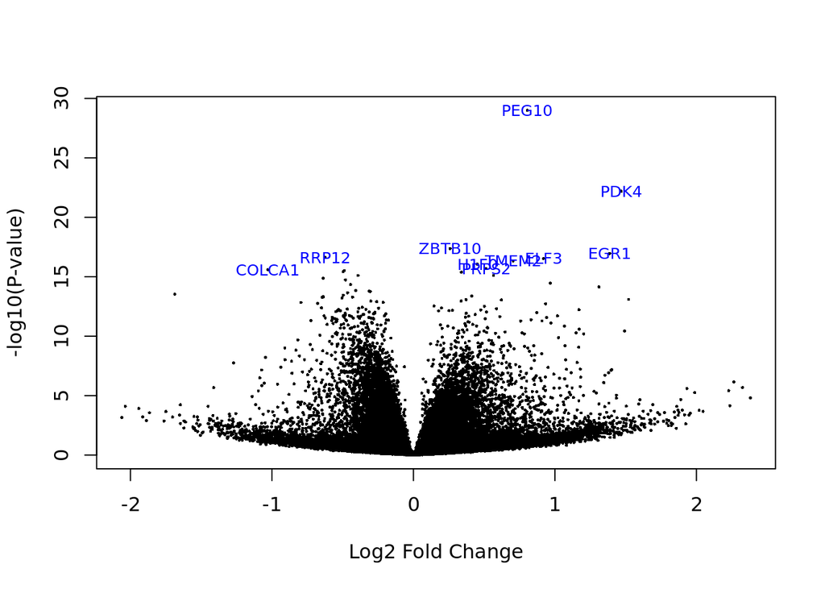

```r
volcanoplot(eb_results, coef = 2, highlight = 10, names = de_results$gene_name)
```

# Visualización

se trabajara con los primero 20, para que la visualización sea adecuada

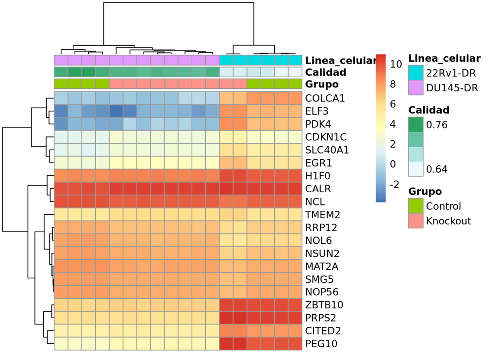

```r
exprs_heatmap <- vGene$E[rank(de_results$adj.P.Val) <= 20, ]
df <- as.data.frame(colData(rse)[, c("POM121","assigned_gene_prop","sra_attribute.cell_line")])
colnames(df) <- c("Grupo","Calidad","Linea_celular")

rownames(exprs_heatmap) <- rowRanges(rse)$gene_name[
    match(rownames(exprs_heatmap), rowRanges(rse)$gene_id)
]

library("pheatmap")
pheatmap(
    exprs_heatmap,
    cluster_rows = TRUE,
    cluster_cols = TRUE,
    show_rownames = TRUE,
    show_colnames = FALSE,
    annotation_col = df
)
```

El heatmap muestra que loos genes estan separados principalmente por la linea celular a la que pertenecen y dentro de cada una de las lineas se separan por la preencia o ausencia de POM121.

Además que esta grafica nos permite notar de manera clara que la calidad en la linea 22Rv1-DR es mucho menor que en la DU145-DR, lo que podría conllevar problemas.

## Multidimentional scaling

```r
## Para colores
library("RColorBrewer")

## Conviertiendo los grupos a colores
col.group <- df$Grupo
levels(col.group) <- brewer.pal(nlevels(col.group), "Set1")
```

Recordando que el escalado multidimensional permite una representacion visual de los datos con base en su similitud.

### MDS por grupos

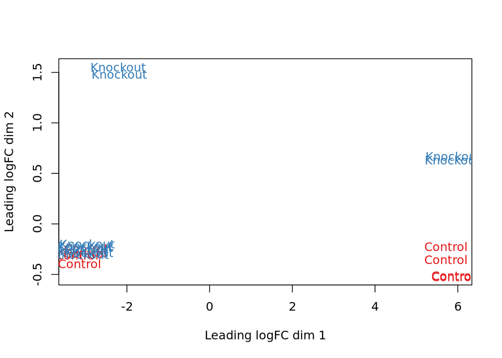

```r
col.group <- as.character(col.group)

plotMDS(vGene$E, labels = df$Grupo, col = col.group)
```

### MDS por linea celular

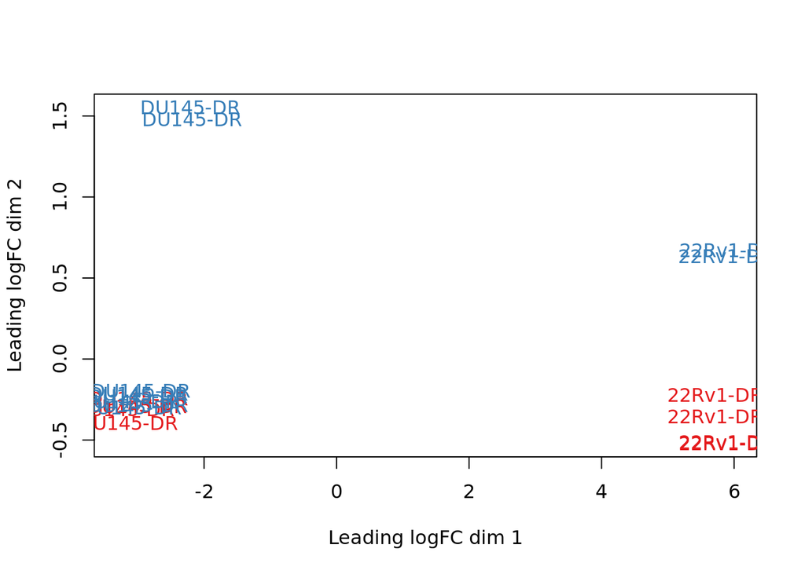

```r
plotMDS(vGene$E, labels = df$Linea_celular, col = col.group)
```

### Uso de iSEE

```r
# library("iSEE")
# iSEE::iSEE(rse)
```

```r
NomGenes[1:5]
```

```
## [1] "MTCO2P12"  "LINC01128" "SAMD11"    "NOC2L"     "HES4"
```

- MTCO2P12 Se trata de pseudo-gen tambien conocido como COX2, es parte de subunidad oxidasa II del citocromo c.
- LINC01128 Una región que no codifica para proteínas que se expresa en diversos tejidos del cuerpo
- NOC2L Es un inhibidor de la histona acetiltransferasa (INHAT), que se encarga de la regulación transcripcional
- SAMD11 Actividad coactivadora de la transcripción y unión al dominio PH
- HES4 Unión del factor de transcripción y actividad de dimerización de proteínas.

## Conclusiones

El knockout de POM121 conlleva a una expresión diferencial entre las muestras, siendo que esta se conserva aún en diferentes lineas celulares, pero considero que para poder llegar a resultados más precisos se necesita que las diferencias de expresión de genes que ya existen entre las lineas, aún sin la afectacion de POM121, sean descartadas, de esa forma los genes que sean resaltados serán los que solo esten siendo influenciados por POM121.

### Referencias

- MTCO2P12 MT-CO2 pseudogene 12 [ Homo sapiens (human) ]; https://www.ncbi.nlm.nih.gov/gene/?term=MTCO2P12
- LINC01128 long intergenic non-protein coding RNA 1128 [ Homo sapiens (human)]; https://www.ncbi.nlm.nih.gov/gene/643837
- NOC2L NOC2 like nucleolar associated transcriptional repressor [ Homo sapiens (human) ];https://www.ncbi.nlm.nih.gov/gene/26155
- SAMD11 Gene; https://www.genecards.org/cgi-bin/carddisp.pl?gene=SAMD11&keywords=SAMD11
- HES4 Gene; https://www.genecards.org/cgi-bin/carddisp.pl?gene=HES4&keywords=HES4
- Talamas JA, Hetzer MW. POM121 and Sun1 play a role in early steps of interphase NPC assembly. J Cell Biol. 2011 Jul 11;194(1):27-37. doi: 10.1083/jcb.201012154. Epub 2011 Jul 4. PMID: 21727197; PMCID: PMC3135402.
- Rodriguez-Bravo V, Pippa R, Song WM, Carceles-Cordon M, Dominguez-Andres A, Fujiwara N, Woo J, Koh AP, Ertel A, Lokareddy RK, Cuesta-Dominguez A, Kim RS, Rodriguez-Fernandez I, Li P, Gordon R, Hirschfield H, Prats JM, Reddy EP, Fatatis A, Petrylak DP, Gomella L, Kelly WK, Lowe SW, Knudsen KE, Galsky MD, Cingolani G, Lujambio A, Hoshida Y, Domingo-Domenech J. Nuclear Pores Promote Lethal Prostate Cancer by Increasing POM121-Driven E2F1, MYC, and AR Nuclear Import. Cell. 2018 Aug 23;174(5):1200-1215.e20. doi: 10.1016/j.cell.2018.07.015. Epub 2018 Aug 9. PMID: 30100187; PMCID: PMC6150493.
- Transcriptome profiles of POM121-knockout prostate cancer cell lines; https://www.ncbi.nlm.nih.gov/geo/query/acc.cgi?acc=GSE103637

## Heatmap de los 100 primeros genes

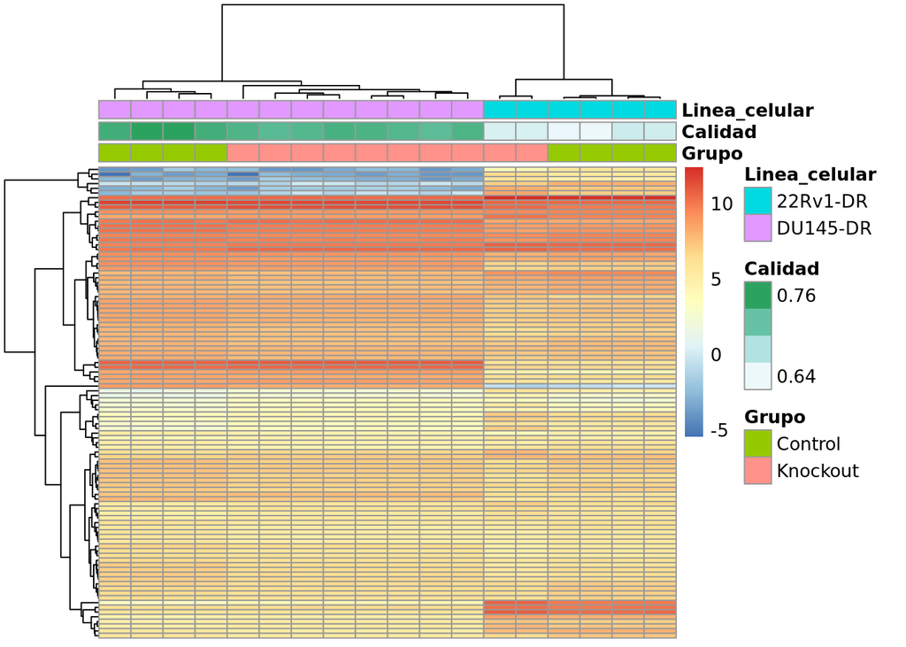

```r
exprs_heatmap <- vGene$E[rank(de_results$adj.P.Val) <= 100, ]
df <- as.data.frame(colData(rse)[, c("POM121","assigned_gene_prop","sra_attribute.cell_line")])
colnames(df) <- c("Grupo","Calidad","Linea_celular")

library("pheatmap")
pheatmap(
    exprs_heatmap,
    cluster_rows = TRUE,
    cluster_cols = TRUE,
    show_rownames = FALSE,
    show_colnames = FALSE,
    annotation_col = df
)
```